# Assignment webscraping

Student 1: Jane Shadrina

Student 2: Paul Marie Mweni

Student 3: Moustafa Basiony

Student 4: Tolulope Soetan

2025-12-07

# Instructions

- Answer the questions below in this R Markdown file;
- Explain your coding decisions and output in detail;
- Knit the file to HTML;
- Send the knitted HTML file, together with the raw `rmd` file to Cecil.Meeusen@kuleuven.be;
- Make sure your documents are named like this: ‘Assignment_3_GROUP_X’;
- Don’t forget to fill out the group members names in the YAML header;
- This group assignment counts for 1 out of 20 grades;
- This is a GROUP assignment for groups consisting of 3-4 members. If you to not meet this guideline, this will result in a 0/1 for this assignment.
- You may receive questions about this assignment during the oral exam; if you do not submit this assignment, you may still receive questions about it during the oral exam.
- The use of GenAI is allowed, but should be clearly acknowledged in the designated section below. Be as transparent as possible. Unauthorized use of genAI can have severe consequences. For guidelines see https://www.kuleuven.be/english/genai
- Your assignment will be evaluated based on following criteria:
  - Overall insight and depth
  - Correctness of answers
  - Coherence/logical composition/structure answers
  - Interpretation of results
  - Structure of code and annotations
  - Appropriate use of tables and visualisations
  - Appropriate use of genAI and course material

# Case/data description: Jobat data

Jobat is a Belgian website where you can find a lot of job vacancies: https://www.jobat.be/en

Your job is to scrape the website and explore the vacancies that are currently published.

You can scrape the webpage in Dutch or in English.

```r
library(htmltools)
library(rvest)
library(tidyverse)
library(httr)
```

# 1. Webscraping 1.0

1. Are you allowed to scrape data from the Jobat website? Explain in detail how you have checked this and what is or is not allowed to be scraped from this website.

**Answer**: In order to check whether we are allowed to scrape data from the Jobat website, we visited https://www.jobat.be/robots.txt to check the pages that are allowed to be scraped. Some pages are disallowed. Those pages include: search pages, API endpoints, login pages, and old job or company listings. But the ICT job listings page ’(en/jobs/ict) is not disallowed thus scraping the page is allowed. Certain bots like DataForSeoBot and PetalBot are blocked, although using an individual or a custom browser-like User-Agent ensures compliance with these rules. Therefore, scraping the ICT job vacancies to conduct research is within the guidelines of the website.

2. The jobs are classified in 4 categories: “logistics, transport & purchase”, “technics, engineering, production”, “ICT”, and “Social, cultural and sports”. Scrape the job titles of the first 50 ICT related job vacancies: https://www.jobat.be/en/jobs/ict. Take into account good practices related to webscraping!

```r
library(rvest)
library(httr)
library(tidyverse)
library(tidytext)
library(stringr)
library(wordcloud)
library(RColorBrewer)

url <- "https://www.jobat.be/en/jobs/ict"

# Reading the page HTML
ict_page <- read_html(url)

# Extracting job titles using the CSS selector
job_titles <- ict_page %>%
  html_nodes("h2.jobTitle a") %>%   # select <a> inside <h2 class="jobTitle">
  html_text(trim = TRUE)            # extract the text


# Scraping only the first 50 ict job titles
job_titles_50 <- job_titles[1:50]

# Displaying the first 50 ict job titles
job_titles_50
```

```
##  [1] "Zscaler Specialist (NL/ENG)"
##  [2] "L3 Network, Security and System Engineer"
##  [3] "Software Tester"
##  [4] "C++ Developer"
##  [5] "Allround IT Medewerker"
##  [6] "Project Portfolio Manager"
##  [7] "Master Data Officer"
##  [8] "SAP Analist | Chemische sector"
##  [9] "IT Hardware Support Engineer"
## [10] "IT Infrastructuur Coördinator"
## [11] "Supervisor (Systems & Accounts)"
## [12] "IT Business Analyst"
## [13] "IT Business Analyst"
## [14] "Master Data"
## [15] "IT Business Analyst SAP"
```

[output cut: 35 more lines]

3. At this point, you only scraped the first 50 job vacancies. Now, loop over the different pages, scraping *all* ICT related job vacancies posted on the website. Save the results in one dataframe. Build in a crawl delay of 10 seconds.

*a) How many job vacancies have you extracted?*

**Note**: In our initial attempt to scrape the ICT job vacancies, the default page URLs ( **?p=**) returned 0 results. After reviewing the website structure, we realized that the ICT job vacancies pages are 3 and the page URLs use the **?pagenum**= format. We updated the URLs using the pagenum format, and the loop successfully extracted all job titles as required. The following function-based loop successfully scraped all ICT job vacancies across the three pages.

```r
# writing Function to scrape one page
scrape_page <- function(url) {

  # Sending request with user-agent
  req <- GET(url,
             user_agent = "paulmariemutamba.mweni@student.kuleuven.be, Moustafa.basiony@student.kuleuven.be, tolulopeolaide.soetan@student.kuleuven.be, evgeniia.shadrina@student.kuleuven.be; Assignment class collecting and analysing big data"
  )

  # If request fails, doing a break
  if (status_code(req) != 200) {
    cat("Failed to load:", url, "\n")
    return(character(0))
  }

  # Reading the page
  page <- read_html(req)

  # Extracting job titles
  titles <- page %>%
    html_nodes("h2.jobTitle a") %>%
    html_text(trim = TRUE)

  # printing the titles back from the function
  return(titles)
}

# creating empty vector to store all job titles
all_titles <- c()

# Total number of pages to scrape (as discovered)
total_pages <- 3

# Looping over pages
for (page_num in 1:total_pages) {

  # Building page URL
  if (page_num == 1) {
    url <- "https://www.jobat.be/en/jobs/ict"
  } else {
    url <- paste0("https://www.jobat.be/en/jobs/ict?pagenum=", page_num)
  }

  # Displaying which page is being scraped
  cat("Scraping page:", page_num, "\n")

  # Scraping job titles
  titles <- scrape_page(url)

  # Adding titles to the empty vector created
  all_titles <- c(all_titles, titles)

  # Sleep timer
  Sys.sleep(10)
}
```

```
## Scraping page: 1
## Scraping page: 2
## Scraping page: 3
```

```r
df2 <- data.frame(title = all_titles)

nrow(df2)
```

```
## [1] 123
```

```r
head(df2, 20)
```

```
##                                       title
## 1               Zscaler Specialist (NL/ENG)
## 2  L3 Network, Security and System Engineer
## 3                           Software Tester
## 4                             C++ Developer
## 5                    Allround IT Medewerker
## 6                 Project Portfolio Manager
## 7                       Master Data Officer
## 8            SAP Analist | Chemische sector
## 9              IT Hardware Support Engineer
## 10            IT Infrastructuur Coördinator
## 11          Supervisor (Systems & Accounts)
## 12                      IT Business Analyst
## 13                      IT Business Analyst
## 14                              Master Data
## 15                  IT Business Analyst SAP
## 16              IT Test Automation Engineer
## 17 Software Support Engineer | 2d Thuiswerk
## 18       IT & Telecom Specialist |VoIP & UC
## 19                         It Analyst- D365
## 20                    Software Configurator
```

*b) Preprocess the job titles and make a wordcloud. Explain your preprocessing steps.*

**Preprocessing Steps:**

For preprocessing of the scraped job titles before creating the wordcloud, we performed some standard text-cleaning steps. We converted all text to lowercase, removed punctuation, removed numbers, removed common stopwords such as “the”, “and”, “with”, etc since all these words do not provide any meaningful information. Also, we removed extra whitespaces, tokenized the words, i.e. split them into single words, and calculated the word frequencies to prepare the data for making the wordcloud.

Preprocessing the job titles:

```r
titles <- df2$title

titles_clean <- titles %>%
  str_to_lower() %>%                       # Converting to lowercase
  str_replace_all("[[:punct:]]", " ") %>%  # Removing punctuation
  str_replace_all("[0-9]", " ") %>%        # Removing numbers
  str_squish()                             # Removing extra whitespaces

# Converting to dataframe for tidytext
titles_df <- data.frame(title = titles_clean, stringsAsFactors = FALSE)

# Tokenizing words
tidy_titles <- titles_df %>%
  unnest_tokens(word, title)

# Removing common stopwords
data("stop_words")
tidy_titles <- tidy_titles %>%
  anti_join(stop_words, by = "word")

# Counting word frequencies
word_freq <- tidy_titles %>%
  count(word, sort = TRUE)

head(word_freq, 20)
```

```
##             word  n
## 1       engineer 39
## 2      developer 18
## 3        support 18
## 4         senior 13
## 5           data 10
## 6       software 10
## 7     specialist 10
## 8        analyst  9
## 9       business  9
## 10         stack  9
## 11           sap  8
## 12        system  8
## 13           net  7
## 14      security  7
## 15     thuiswerk  7
## 16       analist  6
## 17    consultant  6
## 18           erp  6
## 19          java  6
## 20 bedrijfswagen  5
```

Making a Wordcloud for the job titles:

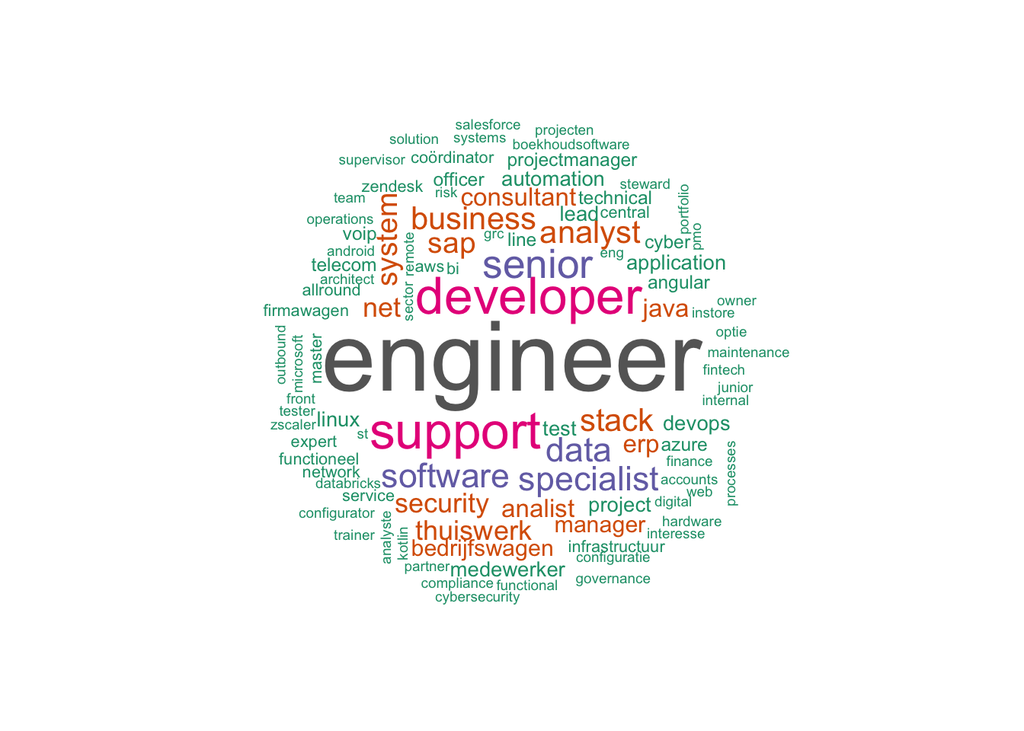

```r
set.seed(123)

wordcloud(words = word_freq$word,
          freq = word_freq$n,
          min.freq = 1,
          max.words = 100,
          random.order = FALSE,
          colors = brewer.pal(8, "Dark2"))
```

*c) What are the most common collocations in the jobtitles?*

```r
# Creating bigrams (2-word collocations)
bigrams <- titles_df %>%
  unnest_tokens(bigram, title, token = "ngrams", n = 2)

# Separating the two words
bigrams_separated <- bigrams %>%
  separate(bigram, into = c("word1", "word2"), sep = " ")

# Removing stopwords in either word
bigrams_filtered <- bigrams_separated %>%
  filter(!word1 %in% stop_words$word,
         !word2 %in% stop_words$word)

# Counting bigram frequencies
bigram_counts <- bigrams_filtered %>%
  unite(bigram, word1, word2, sep = " ") %>%
  count(bigram, sort = TRUE)

# Top 20 collocations
head(bigram_counts, 20)
```

```
##                 bigram  n
## 1     support engineer 11
## 2      system engineer  6
## 3     business analyst  5
## 4        net developer  5
## 5  automation engineer  4
## 6        data engineer  4
## 7      devops engineer  4
## 8          erp support  4
## 9       java developer  4
## 10           stack net  4
## 11     test automation  4
## 12         analyst sap  3
## 13      cyber security  3
## 14        line support  3
## 15        linux system  3
## 16     project manager  3
## 17   software engineer  3
## 18          stack java  3
## 19  support specialist  3
## 20   angular developer  2
```

# 2. Webscraping 2.0

1. Scrape the *jobtitles*, *location* of the position (Antwerp, Brussels…), *type of contract* (permanent, freelance, fixed-term…), and the *salary range* for all jobs in ICT. Make one dataframe including all four features (‘jobtitle’, ‘location’, ‘contract’, ‘salary’).

Tip: If you scrape all four features separately and merge afterwards, your merge will be messy. For example: for some jobtitles, the salary range may be missing, but will not be automatically filled with ‘NA’ but with the salary range of the next hit. A solution is to **scrape the full job description first** and then **parse the different elements** from that jobdescription. This way, automatic `NA` will appear where needed.

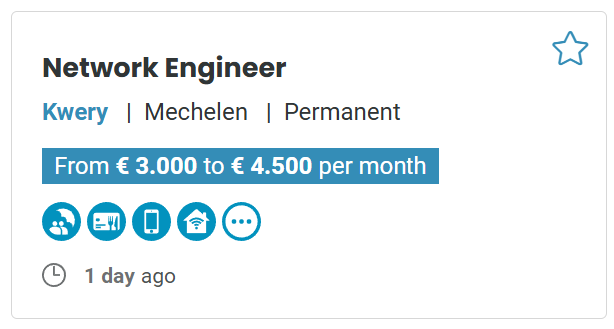

```r
ictjobtitles <- ict_page %>% html_nodes(".jobTitle a") %>% html_text()
full_job_description <- ict_page %>% html_nodes(".open") %>% html_text()
```

In this initial exploration, we extract two key pieces of information from the first page of ICT job listings:

Job Titles (ictjobtitles): We use the CSS selector .jobTitle a to target all hyperlinks within elements that have the class “jobTitle”. Full Job Descriptions (full_job_description): We use the .open selector to capture the complete job card information. Each job card contains multiple pieces of information (title, location, contract type, salary)

```r
parse_job_card <- function(raw_text) {

  # Split the raw string by new lines and remove whitespace/empty lines
  lines <- raw_text %>%
    str_split("\r\n") %>%
    unlist() %>%
    str_trim() %>%
    discard(~ .x == "") # Remove empty strings

  # --- EXTRACTION LOGIC ---

  # Title: Typically the first non-empty line
  title <- if(length(lines) >= 1) lines[1] else NA

  # Contract: Search for specific keywords
  # We look for the index of the line that contains the contract type
  contract_types <- "(Permanent|Freelance|Fixed-term|Student job|Internship|Starter|Interim|Self)"
  contract_index <- which(str_detect(lines, regex(contract_types, ignore_case = TRUE)))[1]

  contract <- if(!is.na(contract_index)) lines[contract_index] else NA

  # Location:
  # Heuristic -> In this HTML structure, Location is usually the line immediately BEFORE Contract
  location <- if(!is.na(contract_index) && contract_index > 1) {
    lines[contract_index - 1]
  } else {
    NA
  }

  # Salary: Search for currency symbol
  salary_index <- which(str_detect(lines, "€"))[1]
  salary <- if(!is.na(salary_index)) lines[salary_index] else NA

  # Return as a one-row tibble
  tibble(
    Title = title,
    Location = location,
    Contract = contract,
    Salary = salary
  )
}

df_jobs <- map_dfr(full_job_description, parse_job_card)

# 3. View Result
print(df_jobs)
```

```
## # A tibble: 50 × 4
##    Title                                    Location         Contract  Salary
##    <chr>                                    <chr>            <chr>     <chr>
##  1 Zscaler Specialist (NL/ENG)              Multiple regions Permanent <NA>
##  2 L3 Network, Security and System Engineer Vorst            Permanent <NA>
##  3 Software Tester                          Antwerp          Permanent From € 3…
##  4 C++ Developer                            Roeselare        Permanent From € 3…
##  5 Allround IT Medewerker                   Bruges           Permanent From € 3…
##  6 Project Portfolio Manager                Brussels         Permanent <NA>
##  7 Master Data Officer                      Waregem          Permanent From € 3…
##  8 SAP Analist | Chemische sector           Antwerp          Permanent From € 3…
##  9 IT Hardware Support Engineer             Ostend           Permanent From € 2…
## 10 IT Infrastructuur Coördinator            Antwerp          Permanent From € 4…
## # ℹ 40 more rows
```

This AI-generated function reliably extracts the four required variables from each job card by using the actual textual structure of the “.open” div.

**How the function works:**

Text splitting: The raw text is split by line breaks (), trimmed of whitespace, and empty lines are removed. This gives us a clean vector of text lines to work with.

**Feature extraction using different strategies:**

Title: Assumes the first non-empty line is always the job title

Contract type: Uses pattern matching with regex to search for keywords like “Permanent”, “Freelance”, “Fixed-term”, etc.

Location: Exploits the HTML structure where location consistently appears on the line immediately before the contract type

Salary: Identifies lines containing the euro symbol (€)

**Handling missing data:**

Each extraction includes conditional logic (if-else statements) to assign NA when information is absent.

```r
dfs=list()
for (i in 1:3){
  url = paste0("https://www.jobat.be/en/jobs/ict?pagenum=", i)
  r = GET(url,
    user_agent="paulmariemutamba.mweni@student.kuleuven.be, Moustafa.basiony@student.kuleuven.be, tolulopeolaide.soetan@student.kuleuven.be, evgeniia.shadrina@student.kuleuven.be; Assignment class collecting and analysing big data")
  page = read_html(r)

  full_job_description <- page %>% html_nodes('.open') %>% html_text()

  df_jobs <- map_dfr(full_job_description, parse_job_card)

  dfs[[i]] <- df_jobs

  Sys.sleep(10)
}
```

This loop systematically scrapes multiple pages of ICT job listings while following ethical web scraping practices. We iterate through 3 pages to collect all of ICT positions without overburdening the server.

**How the loop works:**

URL construction: For each iteration, we dynamically build the URL by appending ?p agenum= followed by the page number (1, 2, 3) Polite requests: Each GET request includes our user agent string identifying ourselves and the academic purpose of our scraping

**Why we used a for loop instead of a while loop**: Known iteration count, we know exactly how many pages we want to scrape (3 pages, which are the entire website at the time of scraping). A for loop is ideal when the number of iterations is predetermined, whereas while loops are better suited for situations where you continue until a condition is met (e.g., “scrape until there are no more pages available”). With a for loop, we have guaranteed termination after exactly 3 iterations, preventing accidental infinite loops that could burden the server. If we are to build a general webscraper that is not affected as time passes and number of postings change, a while loop is more efficient.

```r
library(data.table)
dat <- as.data.frame(rbindlist(dfs))
head(dat)
```

```
##                                      Title         Location  Contract
## 1              Zscaler Specialist (NL/ENG) Multiple regions Permanent
## 2 L3 Network, Security and System Engineer            Vorst Permanent
## 3                          Software Tester          Antwerp Permanent
## 4                            C++ Developer        Roeselare Permanent
## 5                   Allround IT Medewerker           Bruges Permanent
## 6                Project Portfolio Manager         Brussels Permanent
##                              Salary
## 1                              <NA>
## 2                              <NA>
## 3 From € 3.000 to € 4.500 per month
## 4 From € 3.000 to € 5.000 per month
## 5 From € 3.500 to € 5.500 per month
## 6                              <NA>
```

```r
dat$job_cat <- "ICT"
head(dat)
```

```
##                                      Title         Location  Contract
## 1              Zscaler Specialist (NL/ENG) Multiple regions Permanent
## 2 L3 Network, Security and System Engineer            Vorst Permanent
## 3                          Software Tester          Antwerp Permanent
## 4                            C++ Developer        Roeselare Permanent
## 5                   Allround IT Medewerker           Bruges Permanent
## 6                Project Portfolio Manager         Brussels Permanent
##                              Salary job_cat
## 1                              <NA>     ICT
## 2                              <NA>     ICT
## 3 From € 3.000 to € 4.500 per month     ICT
## 4 From € 3.000 to € 5.000 per month     ICT
## 5 From € 3.500 to € 5.500 per month     ICT
## 6                              <NA>     ICT
```

```r
dim(dat)
```

```
## [1] 123   5
```

At this point we have a clean dataframe containing all scraped ICT vacancies with the four requested variables plus a category identifier.  
Missing salary information is correctly coded as NA rather than being shifted from the next record, which confirms that parsing the full job card first was the right strategy.

2. Use the same code to scrape the jobtitles, locations, contract and salary also for the three other job categories. How many jobs are there in each job category?

**Answer:**

Scraping time for this section: 01/12/25, 21:00.

Using the same code for scraping:

```r
dfs=list()
for (i in 1:2){
  url = paste0("https://www.jobat.be/en/jobs/technics-engineering-production?pagenum=", i)
  r = GET(url,
    user_agent="paulmariemutamba.mweni@student.kuleuven.be, Moustafa.basiony@student.kuleuven.be, tolulopeolaide.soetan@student.kuleuven.be, evgeniia.shadrina@student.kuleuven.be; Assignment class collecting and analysing big data")
  page = read_html(r)

  full_job_description <- page %>% html_nodes('.open') %>% html_text()

  df_jobs <- map_dfr(full_job_description, parse_job_card)

  dfs[[i]] <- df_jobs

  Sys.sleep(10)
}
dat_ep <- as.data.frame(rbindlist(dfs))
dat_ep$job_cat <- "TEP"

head(dat_ep)
```

```
##                                           Title         Location  Contract
## 1                           Jet Engine Mechanic   Steenokkerzeel Permanent
## 2               Offshore Service Technician SOV         Oostende Permanent
## 3    Lead Engineer Application Control Platform            Halle Permanent
## 4 Gefahrenverhütungsberater Stufe I – Ingenieur            Liège Permanent
## 5                               Project Manager Multiple regions Permanent
## 6                        Major Projects Manager  Braine-l'Alleud Permanent
##   Salary job_cat
## 1   <NA>     TEP
## 2   <NA>     TEP
## 3   <NA>     TEP
## 4   <NA>     TEP
## 5   <NA>     TEP
## 6   <NA>     TEP
```

```r
dim(dat_ep)
```

```
## [1] 95  5
```

```r
dfs=list()
for (i in 1:2){
  url = paste0("https://www.jobat.be/en/jobs/logistics-transport-purchase?pagenum=", i)
  r = GET(url,
    user_agent="paulmariemutamba.mweni@student.kuleuven.be, Moustafa.basiony@student.kuleuven.be, tolulopeolaide.soetan@student.kuleuven.be, evgeniia.shadrina@student.kuleuven.be; Assignment class collecting and analysing big data")
  page = read_html(r)

  full_job_description <- page %>% html_nodes('.open') %>% html_text()

  df_jobs <- map_dfr(full_job_description, parse_job_card)

  dfs[[i]] <- df_jobs

  Sys.sleep(10)
}
dat_ltp <- as.data.frame(rbindlist(dfs))
dat_ltp$job_cat <- "LTP"

head(dat_ltp)
```

```
##                                 Title Location                        Contract
## 1 Supply Chain Planning Manager - 36h     <NA>                            <NA>
## 2          Forwarding executive agent    Aalst                       Permanent
## 3            Supply Chain Coördinator    Ranst                       Permanent
## 4                  Magazijnier in dag     <NA>                            <NA>
## 5                   Reachtruck driver     Boom Interim optional fixed contract
## 6                Allround magazijnier Mechelen Interim optional fixed contract
##                       Salary job_cat
## 1                       <NA>     LTP
## 2                       <NA>     LTP
## 3                       <NA>     LTP
## 4 From € 17 to € 18 per hour     LTP
## 5                       <NA>     LTP
## 6                       <NA>     LTP
```

```r
dim(dat_ltp)
```

```
## [1] 100   5
```

```r
dfs=list()
for (i in 1:2){
  url = paste0("https://www.jobat.be/en/jobs/finance-insurance-law?pagenum=", i)
  r = GET(url,
    user_agent="paulmariemutamba.mweni@student.kuleuven.be, Moustafa.basiony@student.kuleuven.be, tolulopeolaide.soetan@student.kuleuven.be, evgeniia.shadrina@student.kuleuven.be; Assignment class collecting and analysing big data")
  page = read_html(r)

  full_job_description <- page %>% html_nodes('.open') %>% html_text()

  df_jobs <- map_dfr(full_job_description, parse_job_card)

  dfs[[i]] <- df_jobs

  Sys.sleep(10)
}
dat_fil <- as.data.frame(rbindlist(dfs))
dat_fil$job_cat <- "FIL"

head(dat_fil)
```

```
##                                                  Title
## 1                            HR-Legal Counsel Director
## 2                       Assistant Manager (Compliance)
## 3 Managing Director, State of Illinois European Office
## 4                                     Treasury Officer
## 5                                Reconciliation Expert
## 6                               JUNIOR ACCOUNT MANAGER
##                      Location   Contract                              Salary
## 1 Wevelgem & Zaventem offices  Permanent                                <NA>
## 2   Antwerp & Port of Antwerp  Permanent   From € 4.000 to € 4.500 per month
## 3           Brussels, Belgium Fixed-term From € 90.000 to € 100.000 per year
## 4                    Brussels  Permanent                                <NA>
## 5         Sint-Joost-ten-Node  Permanent                                <NA>
## 6         Sint-Pieters-Woluwe  Permanent   From € 2.600 to € 3.000 per month
##   job_cat
## 1     FIL
## 2     FIL
## 3     FIL
## 4     FIL
## 5     FIL
## 6     FIL
```

```r
dim(dat_fil)
```

```
## [1] 70  5
```

3. Merge your four dataframes together. In what city are the most job openings?

The merged dataset:

```r
finaldf <- rbind(dat, dat_ep, dat_fil, dat_ltp)

head(finaldf)
```

```
##                                      Title         Location  Contract
## 1              Zscaler Specialist (NL/ENG) Multiple regions Permanent
## 2 L3 Network, Security and System Engineer            Vorst Permanent
## 3                          Software Tester          Antwerp Permanent
## 4                            C++ Developer        Roeselare Permanent
## 5                   Allround IT Medewerker           Bruges Permanent
## 6                Project Portfolio Manager         Brussels Permanent
##                              Salary job_cat
## 1                              <NA>     ICT
## 2                              <NA>     ICT
## 3 From € 3.000 to € 4.500 per month     ICT
## 4 From € 3.000 to € 5.000 per month     ICT
## 5 From € 3.500 to € 5.500 per month     ICT
## 6                              <NA>     ICT
```

```r
finaldf %>% group_by(Location) %>% summarise(count = n()) %>% slice_max(count, n = 6)
```

```
## # A tibble: 6 × 2
##   Location   count
##   <chr>      <int>
## 1 <NA>          65
## 2 Antwerp       34
## 3 Brussels      27
## 4 Roeselare     20
## 5 Desteldonk    15
## 6 Ghent         14
```

# Acknowledgement use of genAI

If you have used genAI for this assignment, describe in detail how you have used it. If genAI gave wrong advise, please note this as well and indicate how you debugged the answers. Evaluate yourself: is this appropriate use of genAI (see KU Leuven guidelines)?

**Answer:**

We used generative AI (Claude/ChatGPT). It helped generate the `parse_job_card()` function, which extracts job titles, locations, contract types, and salary information from raw HTML text while properly handling missing values. AI also assisted in refining and polishing the code interpretations. We tested and verified all AI-generated code to ensure it worked correctly, understood the logic behind it. All AI generated code and text were reviewed for accuracy and functionality by our group.